# HW04 Part 1: Complete Chapter 3

Alissa Seal

09 July 2020

## Chapter 3

- Change “your name” in the YAML header above to your name.

### Section 3.1

Load the tidyverse packages. I’ve entered the first code chunk for you. **You must enter all subsequent code chunks and run the code.**

```r
library("tidyverse")
```

If you get an error, then you did not install the `tidyverse` package like you were supposed to in the previous assignment. Go back to that assignment and complete that step. (This should not be the case, though.)

### Section 3.2: First steps

Enter your code chunks for Section 3.2 here.

Get in the habit of entering a brief description of what each chunk of code does. Enter this above the chunk, like I did in Section 3.1.

#### Section 3.2 Questions

Answer the questions *completely.* Some answers will require you to write code in a code chunk and also to type text before or after the chunk. Other answers will require only code or only text.

**1:** Run ggplot(data = mpg). What do you see? An empty graph box

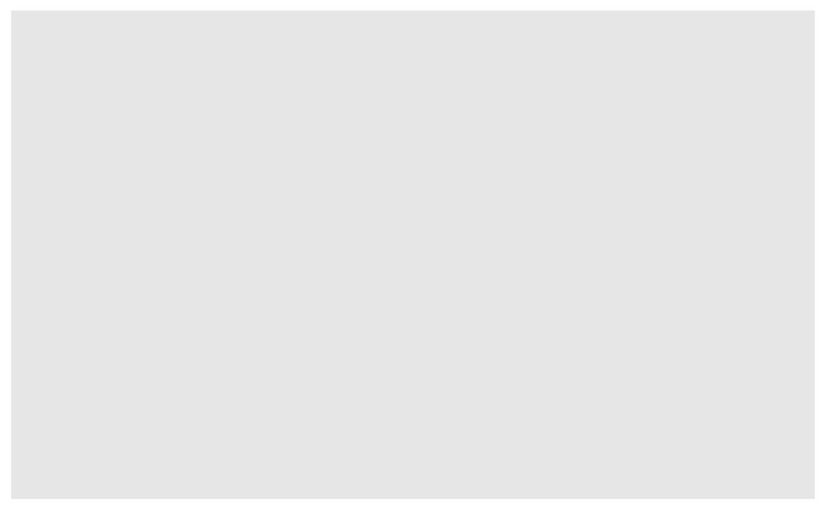

```r
ggplot(data = mpg)
```

**2:** How many rows are in `mpg`? How many columns? **Hint:** Use the `dim()` function. Type `dim()` in the console to learn what `dim()` does.

```r
dim(mpg)
```

```
[1] 234  11
```

**3:** What does the `drv` variable describe? drv variable describes the type of drive train, where f = front-wheel drive, r = rear wheel drive, 4 = 4wd Read the help for `?mpg` to find out.

```r
?mpg
```

**4:** Make a scatterplot of `hwy` vs `cyl`.

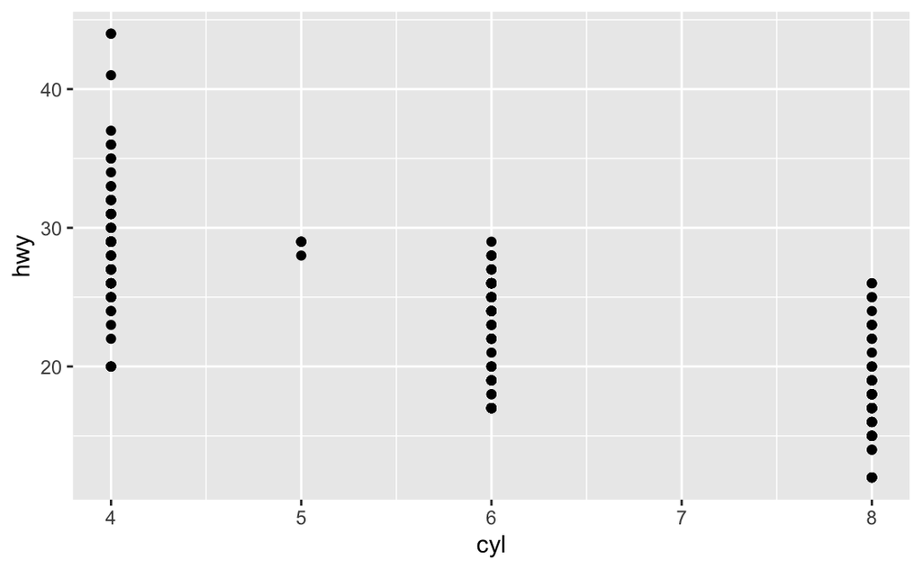

```r
ggplot(data = mpg)+
  geom_point(mapping = aes(x=cyl, y=hwy))
```

**5:** What happens if you make a scatterplot of `class` vs `drv`? Why is the plot not useful? The plot is not useful because the classes of cars can have multiple plots mapped for the type of drive trains available.

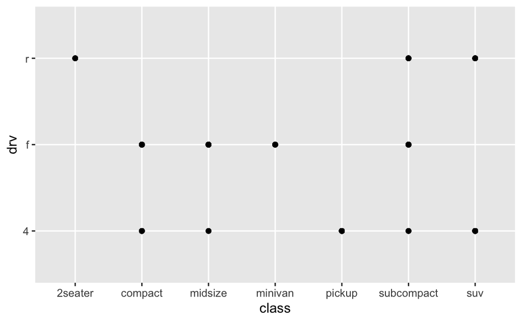

```r
ggplot(data = mpg)+
  geom_point(mapping = aes(x=class, y=drv))
```

### Section 3.3: Aesthetic mappings

#### Section 3.3 questions

**1:** What’s gone wrong with this code? Why are the points not blue? In order to manually set a plot color, the color has to be located outside of the geom function aes()

**2:** Which variables in `mpg` are categorical? Variables that are categorical do not contain an integer or hold a numerical value. So, manufacturer, model, transmission, drive train, fuel type, and class are all categorical variables. Which variables are continuous? The variables that hold a numerical value or is an integer would be a continuous variable. So, displacement, year, cylinder, city mpg, and hwy mpg would be the continuous variables. (*Hint:* type `?mpg` to read the documentation for the dataset). How can you see this information when you run mpg? When running ?mpg it did not return any help or results. An online search suggested running help(mpg) instead. The help results displayed the types of variables listed for the data and described their content.

```r
?mpg
```

```r
help(mpg)
```

**3:** Map a continuous variable to color, size, and shape. How do these aesthetics behave differently for categorical vs. continuous variables? Aesthetics behave best for categorical variables. **Note:** You need several code chunks here to answer this question.

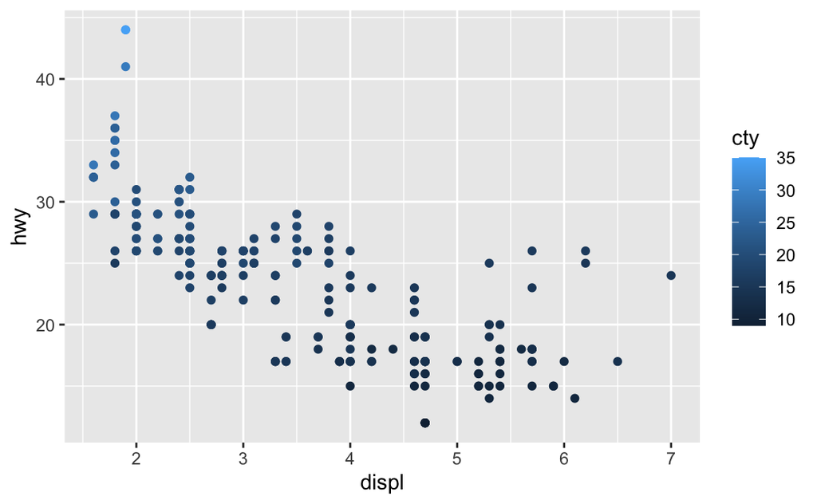

```r
ggplot(data = mpg)+
  geom_point(mapping = aes(x=displ, y=hwy, color=cty))
```

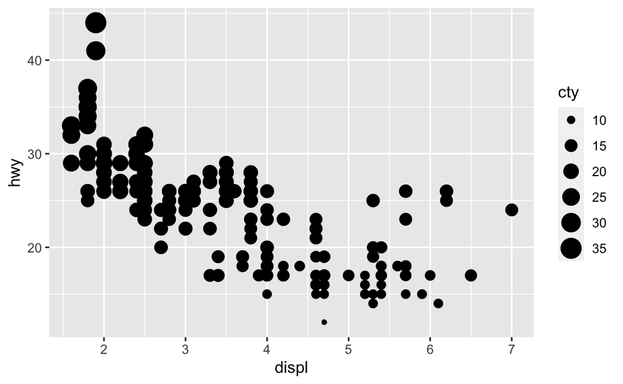

```r
ggplot(data = mpg)+
  geom_point(mapping = aes(x=displ, y=hwy, size=cty))
```

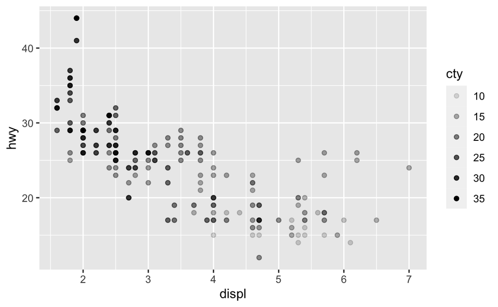

```r
ggplot(data = mpg)+
  geom_point(mapping = aes(x=displ, y=hwy, alpha=cty))
```

```r
ggplot(data = mpg)+
  geom_point(mapping = aes(x=displ, y=hwy, shape=cty))
```

```
Error: A continuous variable can not be mapped to shape
```

**4:** What happens if you map the same variable to multiple aesthetics? In this case, varying classes were distinguished by both different shapes and colors.

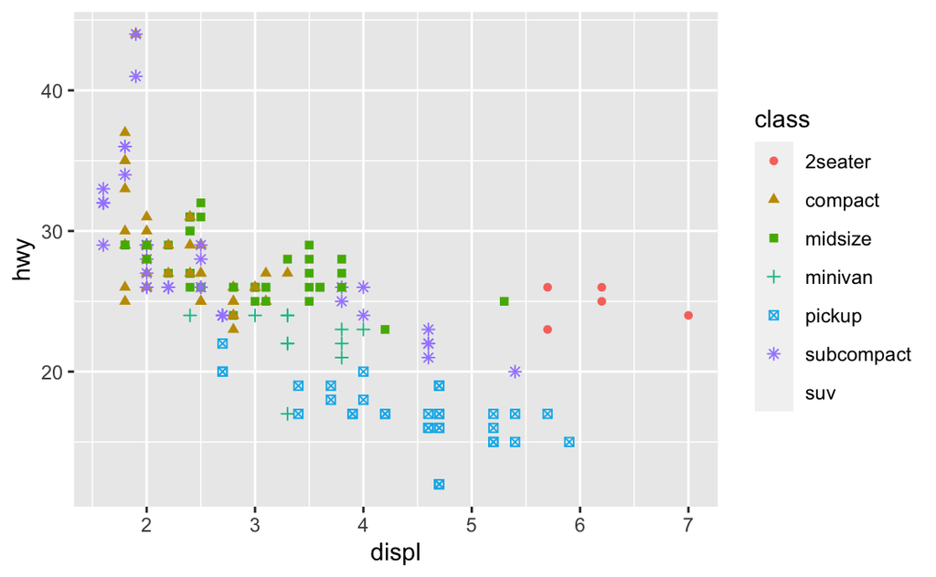

```r
ggplot(data = mpg)+
  geom_point(mapping = aes(x=displ, y=hwy, shape=class, color=class))
```

**5:** What does the stroke aesthetic do? Use the stroke aesthetic to modify the width of the border. What shapes does it work with? Only shapes that have a border. (*Hint:* use `?geom_point`)

```r
?geom_point
```

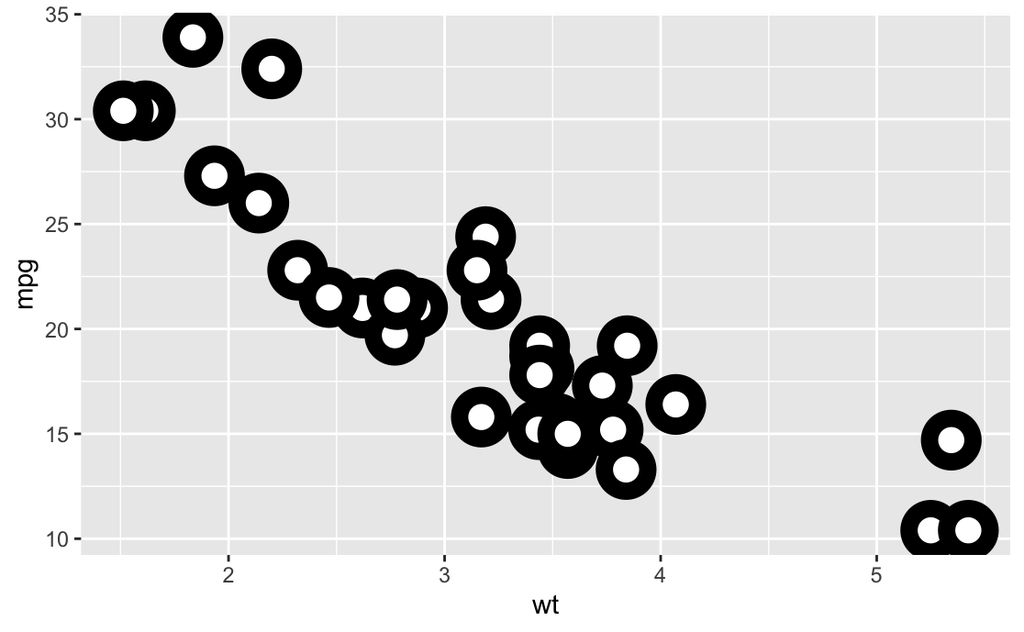

```r
ggplot(mtcars, aes(wt, mpg)) +
  geom_point(shape = 21, colour = "black", fill = "white", size = 5, stroke = 5)
```

**6:** What happens if you map an aesthetic to something other than a variable name, like `aes(colour = displ < 5)`? It displays points in color based on whether they meet the named parameter or not.

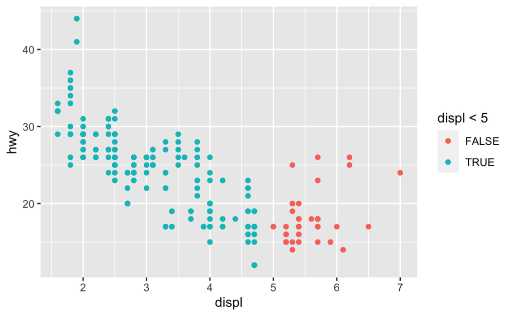

```r
ggplot(data = mpg)+
  geom_point(mapping = aes(x=displ, y=hwy, color= displ <5))
```